# Reproducing Karin et al’s longitudal model of senescent cell growth

# Loading and visualizing the data

```r
snc_counts_fname <- str_c(
  params$data_dir, "raw", "senescent_cells_and_the_dynamics_of_aging__fig_2.csv",
  sep="/"
)
raw_snc_counts <- read.csv(snc_counts_fname, header=TRUE) %>%
  drop_na()
snc_counts <- melt(
  data = raw_snc_counts,
  id.vars = "mouse.week",
  measure.vars = c(
    "X8", "X16", "X24", "X32", "X40", "X48", "X56", "X64", "X72", "X80"
  ),
  value.name = "TBL_x_10_5"
)
snc_counts <- snc_counts %>%
  rename(week = "variable", mouse = "mouse.week")
snc_counts$week <- map_int(snc_counts$week, function (week) { return(as.integer(substr(week, 2, str_length(week)))) })
max(snc_counts$mouse)
```

```
## [1] 32
```

Now we’re going to reproduce Karin et al’s fig. 2a, since it doesn’t require any model-fitting, although we won’t do the nice grey shading they did for now…

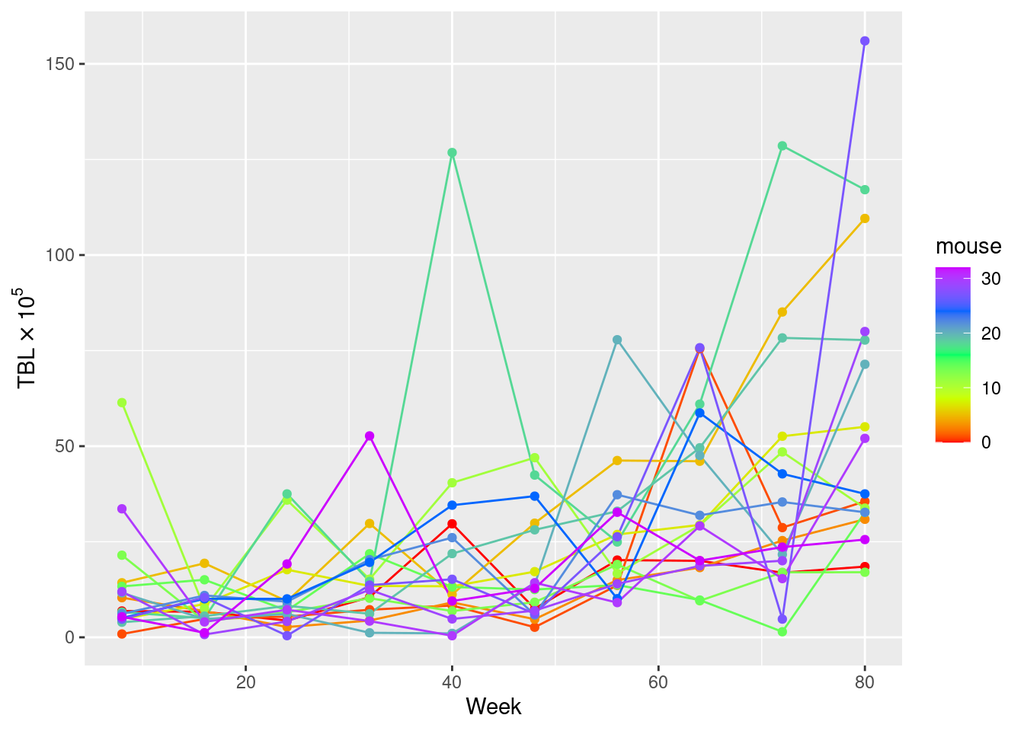

```r
ggplot(
  data = snc_counts,
  aes(x = week, y = TBL_x_10_5, color = mouse, group = mouse)
) +
  xlab("Week") + ylab(TeX("$ TBL \\times 10^5 $")) +
  scale_color_gradientn(colours = rainbow(5)) + geom_line() + geom_point()
```

Next we’re going to replicate the first part of Karin et al’s fig 2c, which shows the mean and standard deviation of normalized senescent cell counts at each week time point.

To normalize senescent cell counts, we adjust all counts to make the mean abundance across the first three measured time points – 8, 16, 24 – equal 1. To do so, we set
$$\beta = \frac{1}{3n} \sum_{i=1}^n \sum_{j \in 8, 16, 24} c_{ij} = 1$$
and divide all counts by it. In other words, normalize by the mean abundance from the first three weeks of data.

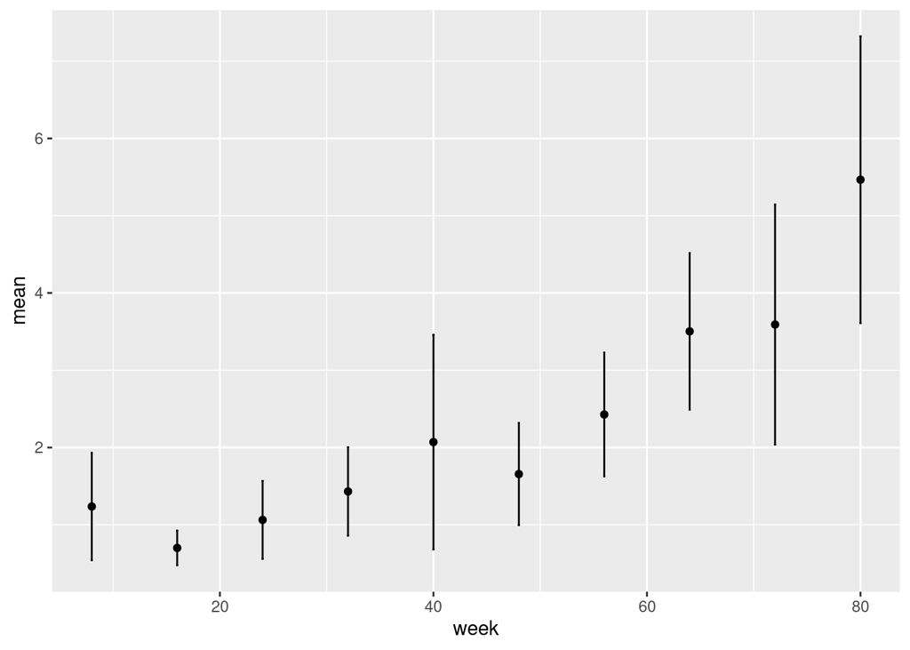

```r
norm_const <- mean(
  snc_counts[snc_counts$week %in% c(8, 16, 24),]$TBL_x_10_5, na.rm = T
)
snc_counts$norm_abundance <- snc_counts$TBL_x_10_5 / norm_const
mean_abundances <- aggregate(
  snc_counts$norm_abundance, list(snc_counts$week), mean, na.rm = T
)$x
stddev_abundances <- aggregate(
  snc_counts$norm_abundance, list(snc_counts$week), sd, na.rm = T
)$x
mean_stddev_abundances <- data.frame(
  mean = mean_abundances,
  stddev = stddev_abundances,
  week = unique(snc_counts$week)
)
p <- ggplot(mean_stddev_abundances, aes(x=week, y=mean)) + geom_point() +
    geom_errorbar(aes(ymin=mean-stddev/2, ymax=mean+stddev/2), width=.2,
                 position=position_dodge(0.05))
print(p)
```

Notably our standard deviation bars seem larger than whatever Karin et al show in their full version of this figure (fig. 2c), but we seem to reproduce their standard error values based on their display of them in fig. 2d.

## Fitting the SR model

As a way to check we haven’t missed something integral to Karin et al’s work, we’re going to fit a Bayesian version of their SR (Saturated-Removal) model and verify that we (hopefully) approximately reproduce their predictive distribution.

Since they did maximum likelihood estimation (with a grid search I’d add) whereas we’re fitting a full posterior distribution with close-to-noninformative prior, we don’t expect exact matching. Because the likelihood includes an ODE, analytically showing the data dominates the prior goes beyond my abilities, but intuitively I expect the posterior predictive distribution to have approximately the same mean as theirs with wider error bars.

```r
# Time series of SnC counts
mice <- unique(snc_counts$mouse)
weeks <- unique(snc_counts$week)
n_mice <- length(mice)
n_weeks <- length(weeks)
print(n_mice)
```

```
## [1] 17
```

```r
snc_abundance <- matrix(nrow = n_mice, ncol=n_weeks)
for (m in 1:n_mice) {
  for (t in 1:n_weeks) {
    week <- weeks[t]
    mouse <- mice[m]
    mouse_week_index <- which(snc_counts$mouse == mouse & snc_counts$week == week)[1]
    snc_abundance[m, t] <- snc_counts$norm_abundance[mouse_week_index]
  }
}

# times
t <- seq(0, n_weeks * 8, by = 8) # 8 hard-coded to match data
t0 = 0
t <- t[-1]

# initial conditions
y0 = c(1)
dim(y0) <- (1)

# data for Stan
data_snc <- list(n_weeks = n_weeks, n_mice = n_mice, y0 = y0, t0 = t0, ts = t, cells = snc_abundance)

# number of MCMC steps
niter <- 2000
```

```r
model <- stan_model("snc_sr_model.stan")
fit_snc_sr_model <- sampling(
  model,
  data = data_snc,
  iter = niter,
  chains = 4
)
```

## Diagnosing model fit

```r
pars=c('eta', 'beta', 'sigma', 'lp__', 'log_likelihood')
print(fit_snc_sr_model, pars = pars, digits_summary = 6)
```

```
## Inference for Stan model: snc_sr_model.
## 4 chains, each with iter=2000; warmup=1000; thin=1;
## post-warmup draws per chain=1000, total post-warmup draws=4000.
##
##                       mean  se_mean       sd        2.5%         25%
## eta[1]            0.267796 0.003797 0.139540    0.041412    0.164186
## eta[2]            0.009294 0.000146 0.005043    0.003374    0.005980
## beta[1]           0.908833 0.010657 0.395677    0.236166    0.616563
## beta[2]           0.783532 0.007368 0.333366    0.211888    0.546602
## sigma             0.899133 0.000901 0.049789    0.808415    0.864285
## lp__            -84.528699 0.097015 3.664896  -92.541482  -86.655464
## log_likelihood -280.205770 0.093672 2.922093 -285.616499 -282.330330
##                        50%         75%       97.5% n_eff     Rhat
## eta[1]            0.253170    0.353459    0.577214  1351 1.002581
## eta[2]            0.008115    0.011030    0.022925  1189 1.002460
## beta[1]           0.877521    1.174995    1.758455  1378 1.002306
## beta[2]           0.752258    0.994429    1.520031  2047 1.000784
## sigma             0.896932    0.930671    1.002227  3053 0.999787
## lp__            -84.173919  -81.981270  -78.180705  1427 1.001410
## log_likelihood -280.231502 -278.082878 -274.604763   973 1.000387
##
## Samples were drawn using NUTS(diag_e) at Sun Dec  6 16:44:39 2020.
## For each parameter, n_eff is a crude measure of effective sample size,
## and Rhat is the potential scale reduction factor on split chains (at
## convergence, Rhat=1).
```

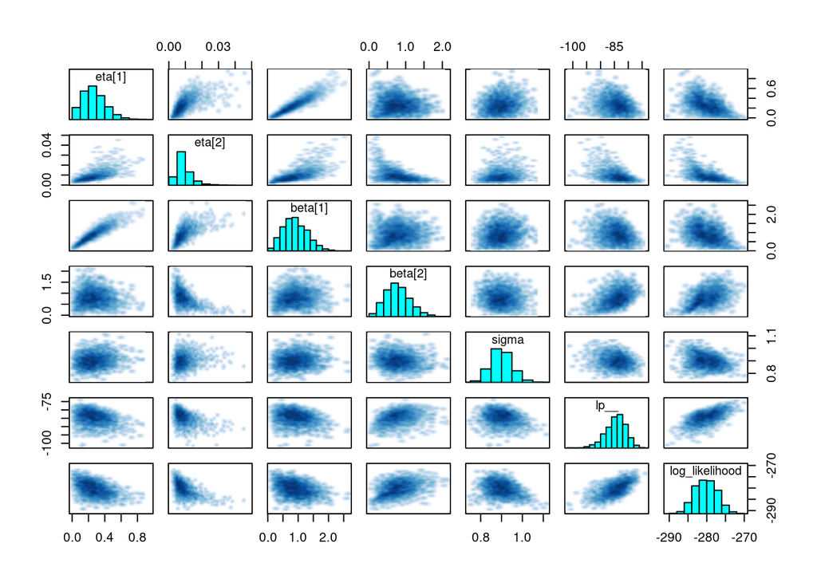

```r
pairs(fit_snc_sr_model, pars=pars)
```

Next, we can look at density plots for our posterior distribution to verify that the posterior distributions look uni-modal (assuming that’s what we want) and relatively similar across chains. In this case, they do!

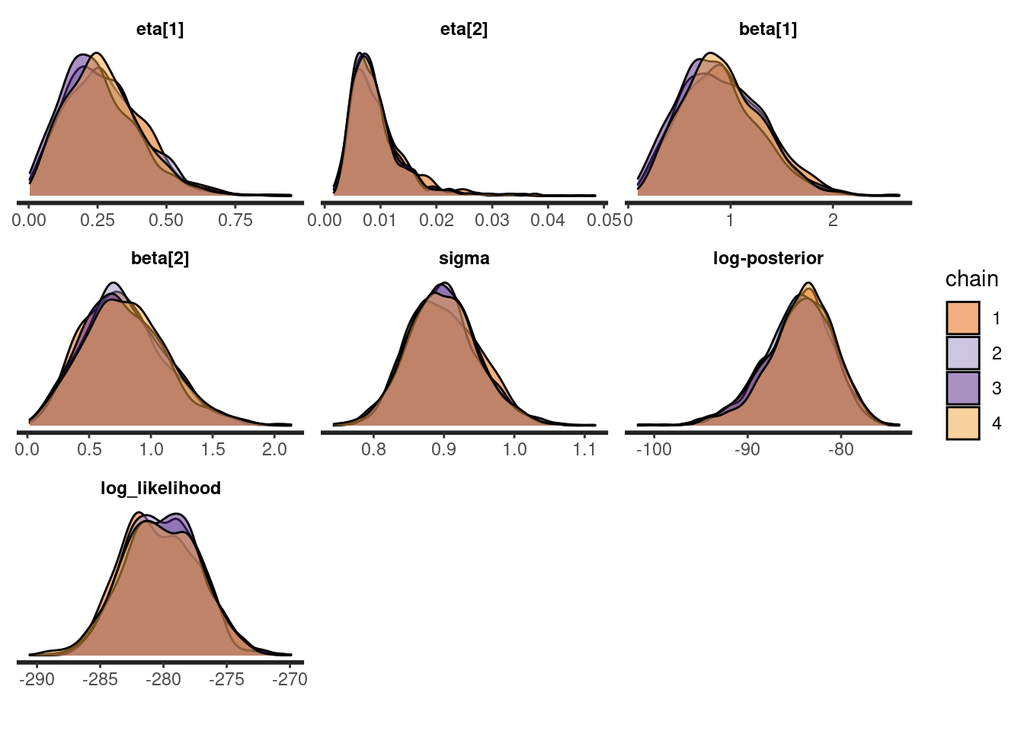

```r
stan_dens(fit_snc_sr_model, pars = pars, separate_chains = TRUE)
```

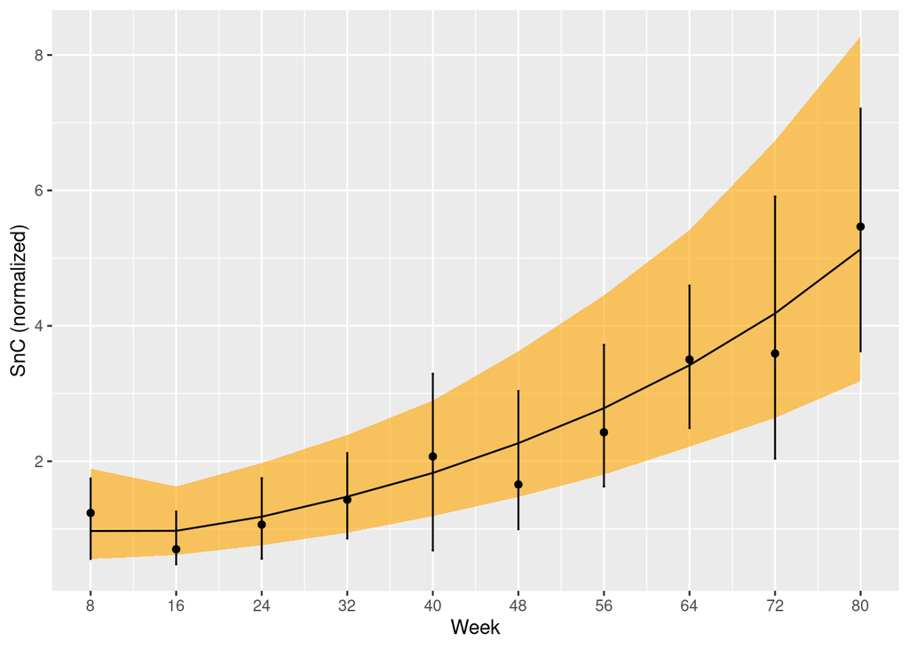

```r
snc_sr_counts_pred <- cbind(
  as.data.frame(
    summary(
      fit_snc_sr_model, pars = "pred_cells_means",
      probs = c(0.05, 0.5, 0.95)
    )$summary
  ),
  t,
  mean_abundances,
  stddev_abundances
)
colnames(snc_sr_counts_pred) <- make.names(colnames(snc_sr_counts_pred)) # to remove % in the col names
ggplot(snc_sr_counts_pred, mapping = aes(x = t)) +
  geom_ribbon(aes(ymin = X5., ymax = X95.), fill = "orange", alpha = 0.6) +
  geom_line(mapping = aes(x = t, y = X50.)) +
  geom_point(mapping = aes(y = mean_abundances)) +
  geom_errorbar(
    aes(
      ymin=mean_abundances - stddev_abundances/2,
      ymax=mean + stddev_abundances/2
    ),
    width=.2,
    position=position_dodge(0.05)
  ) +
  scale_x_continuous(name = "Week", breaks=t, labels=t, limits = c(8, 80)) +
  labs(x = "Week", y = "SnC (normalized)")
```

## Fitting the USR model

Now, to enable us to validate that our comparison produces similar qualitative results to the original paper’s, we’re going to fit a second model. The biggest difference between this model and the first model is that lack of a saturated removal term. The saturated removal term in the prior model is intended to capture the phenomenon in which senescent cells become so abundant that the immune system becomes unable to efficiently remove them.

```r
model <- stan_model("snc_usr_model.stan")
fit_usr_model <- sampling(
  model,
  data = data_snc,
  iter = niter,
  chains = 4
)
```

## Diagnosing model fit

We look at the same diagnostics as previously and again find that our chains have mixed and our $n_{\text{eff}}$s seem reasonable. Our posterior densities also again look (mostly) unimodal.

```r
pars=c('eta', 'beta', 'sigma', 'log_likelihood', 'lp__')
print(fit_usr_model, pars = pars)
```

```
## Inference for Stan model: snc_usr_model.
## 4 chains, each with iter=2000; warmup=1000; thin=1;
## post-warmup draws per chain=1000, total post-warmup draws=4000.
##
##                   mean se_mean   sd    2.5%     25%     50%     75%   97.5%
## eta[1]            0.55    0.01 0.21    0.17    0.41    0.55    0.69    0.98
## eta[2]            0.01    0.00 0.01    0.00    0.00    0.01    0.01    0.03
## beta[1]           1.12    0.01 0.38    0.37    0.86    1.11    1.38    1.88
## beta[2]           0.01    0.00 0.00    0.00    0.01    0.01    0.01    0.02
## sigma             0.91    0.00 0.05    0.82    0.87    0.91    0.94    1.01
## log_likelihood -281.89    0.04 1.61 -285.85 -282.68 -281.56 -280.77 -279.98
## lp__            -90.27    0.11 3.54  -98.50  -92.34  -89.98  -87.66  -84.60
##                n_eff Rhat
## eta[1]          1467    1
## eta[2]          2097    1
## beta[1]         1324    1
## beta[2]         1370    1
## sigma           4787    1
## log_likelihood  1279    1
## lp__            1040    1
##
## Samples were drawn using NUTS(diag_e) at Sun Dec  6 16:57:14 2020.
## For each parameter, n_eff is a crude measure of effective sample size,
## and Rhat is the potential scale reduction factor on split chains (at
## convergence, Rhat=1).
```

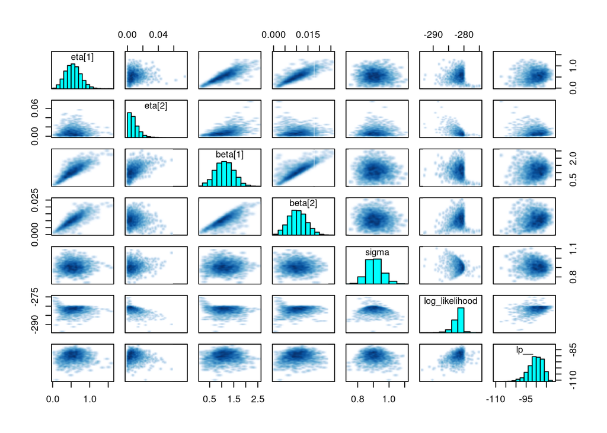

```r
pairs(fit_usr_model, pars = pars)
```

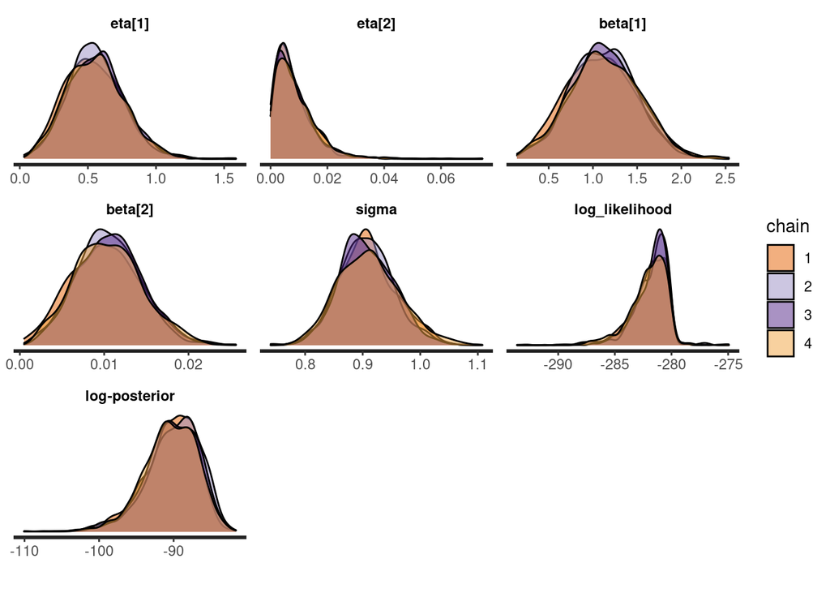

```r
stan_dens(fit_usr_model, pars = pars, separate_chains = TRUE)
```

Finally, we can again look at how well our posterior intervals capture the true data points. To make qualitative comparison with the prior model easier we plot both model’s fits on the graph.

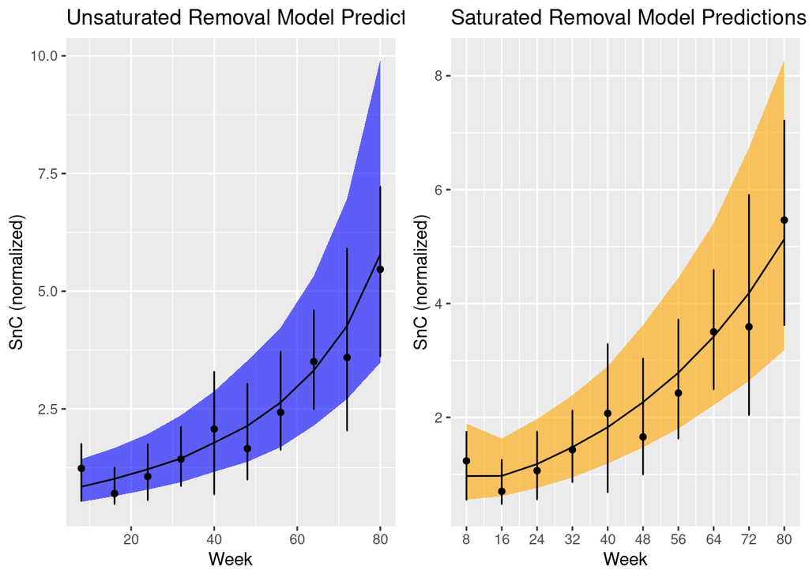

```r
snc_usr_counts_pred <- cbind(
  as.data.frame(
    summary(
      fit_usr_model, pars = "pred_cells_means",
      probs = c(0.05, 0.5, 0.95)
    )$summary
  ),
  t,
  mean_abundances,
  stddev_abundances
)
colnames(snc_usr_counts_pred) <- make.names(colnames(snc_usr_counts_pred)) # to remove % in the col names
p_usr <- ggplot(snc_usr_counts_pred, mapping = aes(x = t)) +
  geom_ribbon(aes(ymin = X5., ymax = X95.), fill = "blue", alpha = 0.6) +
  geom_line(mapping = aes(x = t, y = X50.)) +
  geom_point(mapping = aes(y = mean_abundances)) +
  geom_errorbar(
    data = snc_sr_counts_pred,
    aes(
      ymin=mean_abundances - stddev_abundances/2,
      ymax=mean + stddev_abundances/2,
    ),
    width=.2,
    position=position_dodge(0.05),
  ) +
  labs(title = "Unsaturated Removal Model Predictions", x = "Week", y = "SnC (normalized)", color = "name")

p_sr <- ggplot(snc_sr_counts_pred, mapping = aes(x = t)) +
  geom_ribbon(aes(ymin = X5., ymax = X95.), fill = "orange", alpha = 0.6) +
  geom_line(mapping = aes(x = t, y = X50.)) +
  geom_point(mapping = aes(y = mean_abundances)) +
  geom_errorbar(
    aes(
      ymin=mean_abundances - stddev_abundances/2,
      ymax=mean + stddev_abundances/2
    ),
    width=.2,
    position=position_dodge(0.05)
  ) +
  scale_x_continuous(name = "Week", breaks=t, labels=t, limits = c(8, 80)) +
  labs(title = "Saturated Removal Model Predictions", x = "Week", y = "SnC (normalized)", color = "name")
ggarrange(p_usr, p_sr)
```

Interestingly, our USR graph looks much better than the one in the Alon paper with respect to matching the observations.

Fortunately, since we’re being Bayesian about all this, we can improve over the Alon paper’s original model comparison by using Bayes Factors to compute the odds ratio of our two models’ marginal likelihoods (assuming equal prior probability between the two).

As we expected based on Karin et al, the SNC SR model is deemed much more probable than the USR model. Note that the Bayes factor measures, assuming our two models are denoted $\mathcal{M}_1$, $\mathcal{M}_2$:
$$\frac{P(\mathcal{M}_1 \mid \text{data})}{P(\mathcal{M}_2 \mid \text{data})},$$
so this posterior odds ratio accounts for the relative sizes of the parameter spaces used by the two models.

```r
fit_snc_sr_model.bridge <- bridge_sampler(fit_snc_sr_model, silent = T)
fit_usr_model.bridge <- bridge_sampler(fit_usr_model, silent = T)
bayes_factor(fit_snc_sr_model.bridge, fit_usr_model.bridge)
```

```
## Estimated Bayes factor in favor of x1 over x2: 47.04496
```

```r
post_prob(fit_snc_sr_model.bridge, fit_usr_model.bridge)
```

```
## fit_snc_sr_model.bridge    fit_usr_model.bridge
##              0.97918616              0.02081384
```

# Senescence-Induced Senescence Model

The SIS model seeks to test a hypothesis that senescent cells can be coarsely broken down into long-lived and short-lived senescent cells and that these long-lived cells can induce healthy cells to become (short-lived type) senescent.